# Machine Learning - Assignment 1

### Assumption 3 – Do regional differences influence escalation?

```python
# ── Escalation rate by state (min 100 complaints) ────────────────────────────
state_stats = (
    escalation_stats(df, 'State')
    .query('total >= 100')
)

print(f'States with ≥100 complaints: {len(state_stats)}')
print(f'\nHighest escalation rate: {state_stats["escalation_rate"].max():.1f}% — {state_stats["escalation_rate"].idxmax()}')
print(f'Lowest  escalation rate: {state_stats["escalation_rate"].min():.1f}% — {state_stats["escalation_rate"].idxmin()}')
print(f'Range: {state_stats["escalation_rate"].max() - state_stats["escalation_rate"].min():.1f} percentage points')
print(f'Standard deviation: {state_stats["escalation_rate"].std():.2f}%')
```

```
States with ≥100 complaints: 54

Highest escalation rate: 26.5% — AP
Lowest  escalation rate: 14.8% — SD
Range: 11.6 percentage points
Standard deviation: 2.25%
```

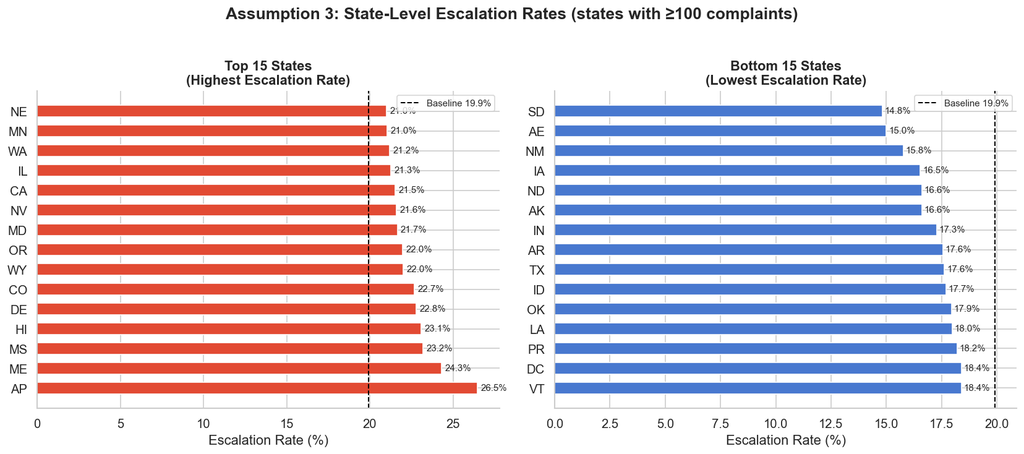

```python
# ── Visual 3a: Top and bottom 15 states ───────────────────────────────────────
top15    = state_stats.head(15)
bottom15 = state_stats.tail(15)

fig, axes = plt.subplots(1, 2, figsize=(14, 6))

axes[0].barh(top15.index, top15['escalation_rate'],
             color='#E24A33', edgecolor='white', height=0.6)
axes[0].axvline(baseline_rate, color='black', linestyle='--', linewidth=1.2,
                label=f'Baseline {baseline_rate:.1f}%')
for i, (idx, row) in enumerate(top15.iterrows()):
    axes[0].text(row['escalation_rate'] + 0.2, i, f"{row['escalation_rate']:.1f}%",
                 va='center', fontsize=9)
axes[0].set_xlabel('Escalation Rate (%)')
axes[0].set_title('Top 15 States\n(Highest Escalation Rate)', fontweight='bold')
axes[0].legend(fontsize=9)
sns.despine(ax=axes[0])

axes[1].barh(bottom15.index, bottom15['escalation_rate'],
             color='#4878CF', edgecolor='white', height=0.6)
axes[1].axvline(baseline_rate, color='black', linestyle='--', linewidth=1.2,
                label=f'Baseline {baseline_rate:.1f}%')
for i, (idx, row) in enumerate(bottom15.iterrows()):
    axes[1].text(row['escalation_rate'] + 0.1, i, f"{row['escalation_rate']:.1f}%",
                 va='center', fontsize=9)
axes[1].set_xlabel('Escalation Rate (%)')
axes[1].set_title('Bottom 15 States\n(Lowest Escalation Rate)', fontweight='bold')
axes[1].legend(fontsize=9)
sns.despine(ax=axes[1])

plt.suptitle('Assumption 3: State-Level Escalation Rates (states with ≥100 complaints)',
             fontweight='bold', y=1.02)
plt.tight_layout()
plt.savefig('fig_state_top_bottom.png', bbox_inches='tight')
plt.show()
```

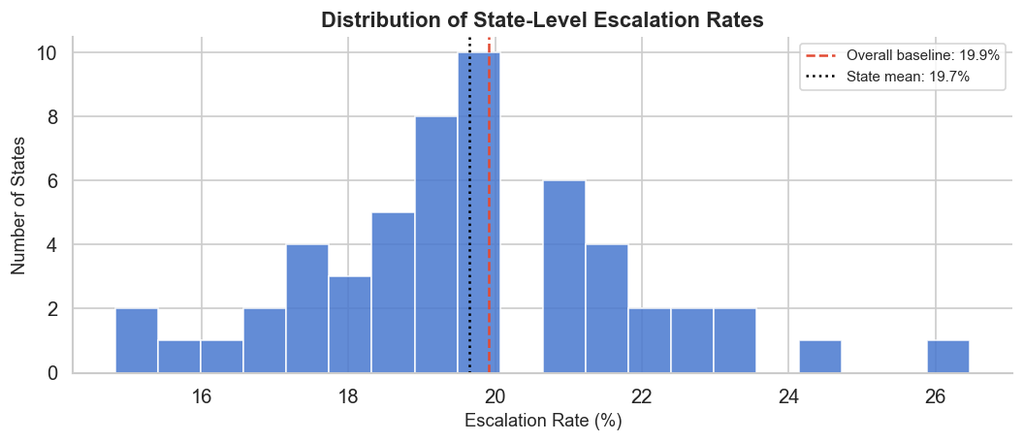

```python
# ── Visual 3b: Distribution of state-level escalation rates ───────────────────
fig, ax = plt.subplots(figsize=(9, 4))
ax.hist(state_stats['escalation_rate'], bins=20, color='#4878CF',
        edgecolor='white', alpha=0.85)
ax.axvline(baseline_rate, color='#E24A33', linestyle='--', linewidth=1.5,
           label=f'Overall baseline: {baseline_rate:.1f}%')
ax.axvline(state_stats['escalation_rate'].mean(), color='black',
           linestyle=':', linewidth=1.5,
           label=f'State mean: {state_stats["escalation_rate"].mean():.1f}%')
ax.set_xlabel('Escalation Rate (%)', fontsize=11)
ax.set_ylabel('Number of States', fontsize=11)
ax.set_title('Distribution of State-Level Escalation Rates',
             fontweight='bold')
ax.legend(fontsize=9)
sns.despine()
plt.tight_layout()
plt.savefig('fig_state_distribution.png', bbox_inches='tight')
plt.show()
```

The geographic data tells that, even restricting to states with at least 100 complaints, there is a wide spread in escalation rates. The histogram shows that while most states cluster around the baseline, a meaningful tail of high-escalation states exists. Let's now confirm this statistically.

```python
# ── Statistical test: State vs Disputed ──────────────────────────────────────
print('Statistical Test: State → Escalation')
print('─' * 50)
chi2_s, p_s, dof_s, v_s = run_chi2(df, 'State')
```

```
Statistical Test: State → Escalation
──────────────────────────────────────────────────
  Chi-squared: χ²=426.3, df=61, p=3.19e-56
  Cramér's V: 0.037 → negligible association
  Significant: YES — statistically significant (p < 0.05)
```

**Conclusion — Assumption 3:**

The assumption is **supported**. The chi-squared test confirms that state significantly predicts escalation (p < 0.001). The range of escalation rates across states is meaningful — some states escalate at nearly double the rate of others. While Cramér's V indicates a modest effect size (geography is one factor among many), the pattern is real and operationally relevant. From a regulatory perspective, this is the most urgent finding: **systematic geographic variation in complaint outcomes can attract scrutiny from the CFPB and state regulators**. Meridian should investigate whether these differences reflect inconsistent response practices, regional product concentrations, or local regulatory environments.

### Q1.1 – Summary: Executive Assumption Testing

All three assumptions contain a grain of truth, but none tells the full story. Product and region both matter, but the drivers of escalation are multi-dimensional. A predictive model that combines all factors will be far more powerful than acting on any single assumption alone.

## Q1.2

### Insight 1 — How a company responds matters more than whether it responds quickly

Does the type of resolution offered by a company influence whether a consumer escalates their complaint? Let's examine whether different response types are associated with different escalation rates.

```python
# ── Escalation rate by company response type ──────────────────────────────────
response_stats = escalation_stats(df, 'Company response to consumer')
print(response_stats.to_string())
```

```
                                  total  disputed  escalation_rate
Company response to consumer
Closed with explanation          249267     55134            22.12
Closed                             7802      1650            21.15
Closed with non-monetary relief   43402      4990            11.50
Closed with monetary relief       19819      2220            11.20
Untimely response                  1140         0             0.00
```

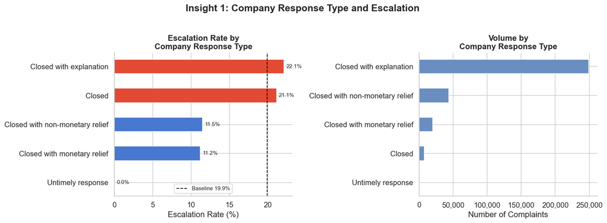

```
Statistical Test:
  Chi-squared: χ²=3922.4, df=4, p=0.00e+00
  Cramér's V: 0.110 → weak association
  Significant: YES — statistically significant (p < 0.05)
```

```
(np.float64(3922.4433462884017), np.float64(0.0), 4, 0.11046765518163706)
```

```python
# ── Visual: Response type vs escalation ──────────────────────────────────────
fig, axes = plt.subplots(1, 2, figsize=(14, 5))

# Left: escalation rate
rs = response_stats.sort_values('escalation_rate')
colors_r = ['#E24A33' if r > baseline_rate else '#4878CF' for r in rs['escalation_rate']]
bars = axes[0].barh(rs.index, rs['escalation_rate'], color=colors_r,
                    edgecolor='white', height=0.5)
axes[0].axvline(baseline_rate, color='black', linestyle='--', linewidth=1.2,
                label=f'Baseline {baseline_rate:.1f}%')
for bar, val in zip(bars, rs['escalation_rate']):
    axes[0].text(val + 0.3, bar.get_y() + bar.get_height()/2,
                 f'{val:.1f}%', va='center', fontsize=9)
axes[0].set_xlabel('Escalation Rate (%)')
axes[0].set_title('Escalation Rate by\nCompany Response Type', fontweight='bold')
axes[0].legend(fontsize=9)
sns.despine(ax=axes[0])

# Right: volume of each response type
rs_vol = response_stats.sort_values('total')
axes[1].barh(rs_vol.index, rs_vol['total'], color='#6A8EBF', edgecolor='white', height=0.5)
axes[1].set_xlabel('Number of Complaints')
axes[1].set_title('Volume by\nCompany Response Type', fontweight='bold')
axes[1].xaxis.set_major_formatter(mticker.FuncFormatter(lambda x, _: f'{int(x):,}'))
sns.despine(ax=axes[1])

plt.suptitle('Insight 1: Company Response Type and Escalation', fontweight='bold', y=1.02)
plt.tight_layout()
plt.savefig('fig_insight1_response.png', bbox_inches='tight')
plt.show()

print('\nStatistical Test:')
run_chi2(df, 'Company response to consumer')
```

Does responding late to a complaint increase the likelihood of escalation? Let's examine whether response timeliness is associated with dispute outcomes.

```python
# ── Timeliness and processing time ───────────────────────────────────────────
timely_stats = escalation_stats(df, 'Timely response?')
print(timely_stats.to_string())

try:
    rr = timely_stats.loc['No', 'escalation_rate'] / timely_stats.loc['Yes', 'escalation_rate']
    print(f'\nRelative risk (late vs timely): {rr:.2f}x')
except:
    pass

# Days from receipt to company send
df['Date received']        = pd.to_datetime(df['Date received'],        errors='coerce')
df['Date sent to company'] = pd.to_datetime(df['Date sent to company'], errors='coerce')
df['days_to_send'] = (df['Date sent to company'] - df['Date received']).dt.days

print('\nDays to send — by dispute outcome:')
print(df.groupby('target')['days_to_send'].describe().round(2))
```

```
                   total  disputed  escalation_rate
Timely response?
Yes               313061     63014            20.13
No                  8369       980            11.71

Relative risk (late vs timely): 0.58x

Days to send — by dispute outcome:
           count  mean    std  min  25%  50%  75%     max
target
0       257436.0  4.03  12.98 -1.0  0.0  0.0  5.0  1270.0
1        63994.0  2.84   8.36 -1.0  0.0  0.0  4.0   755.0
```

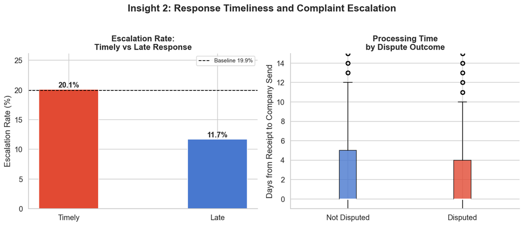

```
Statistical Test:
  Chi-squared: χ²=361.8, df=1, p=1.17e-80
  Cramér's V: 0.034 → negligible association
  Significant: YES — statistically significant (p < 0.05)
```

```
(np.float64(361.7537018860107),
 np.float64(1.1687535988378457e-80),
 1,
 0.03357220399719667)
```

```python
# ── Visual: Timeliness ────────────────────────────────────────────────────────
fig, axes = plt.subplots(1, 2, figsize=(12, 5))

# Left: timely response escalation rate
tr = timely_stats.reset_index()
tr['Timely response?'] = tr['Timely response?'].map({'Yes': 'Timely', 'No': 'Late'})
colors_t = ['#E24A33' if r > baseline_rate else '#4878CF' for r in tr['escalation_rate']]
bars = axes[0].bar(tr['Timely response?'], tr['escalation_rate'],
                   color=colors_t, edgecolor='white', width=0.4)
axes[0].axhline(baseline_rate, color='black', linestyle='--', linewidth=1.2,
                label=f'Baseline {baseline_rate:.1f}%')
for bar, val in zip(bars, tr['escalation_rate']):
    axes[0].text(bar.get_x() + bar.get_width()/2, val + 0.3,
                 f'{val:.1f}%', ha='center', fontsize=12, fontweight='bold')
axes[0].set_ylabel('Escalation Rate (%)')
axes[0].set_ylim(0, tr['escalation_rate'].max() * 1.3)
axes[0].set_title('Escalation Rate:\nTimely vs Late Response', fontweight='bold')
axes[0].legend(fontsize=9)
sns.despine(ax=axes[0])

# Right: days to send — distribution by outcome
data0 = df[df['target'] == 0]['days_to_send'].dropna()
data1 = df[df['target'] == 1]['days_to_send'].dropna()
bp = axes[1].boxplot([data0, data1], labels=['Not Disputed', 'Disputed'],
                     patch_artist=True, notch=False,
                     medianprops=dict(color='white', linewidth=2))
bp['boxes'][0].set_facecolor('#4878CF')
bp['boxes'][1].set_facecolor('#E24A33')
for patch in bp['boxes']:
    patch.set_alpha(0.8)
axes[1].set_ylabel('Days from Receipt to Company Send')
axes[1].set_title('Processing Time\nby Dispute Outcome', fontweight='bold')
axes[1].set_ylim(-1, 15)
sns.despine(ax=axes[1])

plt.suptitle('Insight 2: Response Timeliness and Complaint Escalation',
             fontweight='bold', y=1.02)
plt.tight_layout()
plt.savefig('fig_insight2_timeliness.png', bbox_inches='tight')
plt.show()

print('Statistical Test:')
run_chi2(df, 'Timely response?')
```

**Insight 2 — Conclusion:**

Interestingly, **timely responses show a higher escalation rate than late ones**. This is likely a selection effect: late responses represent a very small fraction of cases and may differ systematically in complexity or product type. Timeliness alone is therefore not a reliable predictor of escalation in isolation.

Are complaints from vulnerable consumer groups — such as Older Americans and Servicemembers — more likely to escalate? Let's examine whether these segments show systematically different dispute rates compared to the general population.

```python
# ── Tags: escalation by consumer segment ─────────────────────────────────────
df['tag_clean'] = df['Tags'].fillna('No Tag')
tag_stats = escalation_stats(df, 'tag_clean')
print(tag_stats.to_string())

tagged = df['Tags'].notna().sum()
print(f'\nTagged complaints: {tagged:,} ({tagged/len(df)*100:.1f}% of total)')
```

```
                                total  disputed  escalation_rate
tag_clean
Older American                  27236      5637            20.70
Older American, Servicemember    4181       865            20.69
Servicemember                   17282      3502            20.26
No Tag                         272731     53990            19.80

Tagged complaints: 48,699 (15.2% of total)
```

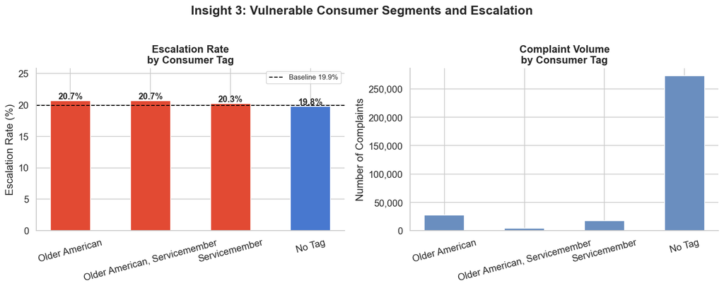

```
Statistical Test:
  Chi-squared: χ²=15.7, df=3, p=1.28e-03
  Cramér's V: 0.007 → negligible association
  Significant: YES — statistically significant (p < 0.05)
```

```
(np.float64(15.743710796289244),
 np.float64(0.001279759310150299),
 3,
 0.006998586707229324)
```

```python
# ── Visual: Tags ──────────────────────────────────────────────────────────────
fig, axes = plt.subplots(1, 2, figsize=(13, 5))

# Left: escalation rate by tag
ts = tag_stats.reset_index()
colors_tag = ['#E24A33' if r > baseline_rate else '#4878CF' for r in ts['escalation_rate']]
bars = axes[0].bar(ts['tag_clean'], ts['escalation_rate'],
                   color=colors_tag, edgecolor='white', width=0.5)
axes[0].axhline(baseline_rate, color='black', linestyle='--', linewidth=1.2,
                label=f'Baseline {baseline_rate:.1f}%')
for bar, val in zip(bars, ts['escalation_rate']):
    axes[0].text(bar.get_x() + bar.get_width()/2, val + 0.2,
                 f'{val:.1f}%', ha='center', fontsize=11, fontweight='bold')
axes[0].set_ylabel('Escalation Rate (%)')
axes[0].set_ylim(0, ts['escalation_rate'].max() * 1.25)
axes[0].set_title('Escalation Rate\nby Consumer Tag', fontweight='bold')
axes[0].legend(fontsize=9)
axes[0].tick_params(axis='x', rotation=15)
sns.despine(ax=axes[0])

# Right: volume breakdown
ts_vol = tag_stats.reset_index()
axes[1].bar(ts_vol['tag_clean'], ts_vol['total'],
            color='#6A8EBF', edgecolor='white', width=0.5)
axes[1].set_ylabel('Number of Complaints')
axes[1].set_title('Complaint Volume\nby Consumer Tag', fontweight='bold')
axes[1].yaxis.set_major_formatter(mticker.FuncFormatter(lambda x, _: f'{int(x):,}'))
axes[1].tick_params(axis='x', rotation=15)
sns.despine(ax=axes[1])

plt.suptitle('Insight 3: Vulnerable Consumer Segments and Escalation',
             fontweight='bold', y=1.02)
plt.tight_layout()
plt.savefig('fig_insight3_tags.png', bbox_inches='tight')
plt.show()

print('Statistical Test:')
run_chi2(df, 'tag_clean')
```

**Insight 3 — Conclusion:**

The volume chart adds important context: the vast majority of complaints carry no tag (~270,000), meaning tagged segments are a small minority. The small effect size suggests that vulnerability tags alone are not a strong driver of escalation and that these consumers escalate at roughly the same rate as everyone else.